# Simulation Study of a Branching Process - Case Study Unit 12

#### Cory Adams, Chris Boomhower, Alexandra Fisher, Alex Frye

#### MSDS 7333, November 29, 2017

*NOTE: We are answering Q.10 from the Data Science in R textbook (Pg. 307): “Carry out a simulation study to see if the re-parameterization suggested in Section 7.9.1 is appropriate. For example, fix kappa to be 1, and run the simulation for various values of lambda. Compare the results to other simulations where kappa is c not equal to 1, but the ratio of lambda/c matches one of the lambda values from the earlier simulation when kappa was 1.”*

## Abstract

In this case study, we conduct a simulation study of the Aldous and Krebs branching process in order to investigate whether re-parameterization of lambda and kappa as a ratio is appropriate for evaluating performance based on different parameter combinations. To do this, we designed several simulations for evaluating outcomes using parameter combination groupings. The Aldous and Krebs process was simulated in R statistical language via the Monte Carlo method. Test simulations were designed and executed for 30 different parameter combinations of lambda and kappa and organized into 10 different ratio groupings, as shown in a parameter matrix output containing associated ratio group numbers and depictions of the lambda/c ratio values themselves. Also, two bar plots were created in order to evaluate any differences between groups that either terminated within a few generations without creating offspring upon completion (groups with more than 20 offspring) versus processes resulting in exponential generation of jobs (groups with 20 generations, a.k.a more than 1,000 offspring). Although no visible differences in proportions were observed between the two bar plots, differences were found within each bar plot not only between ratio sizes, but also within ratios, although to a lesser extent. These findings suggest that parameters could indeed be simplified. As additional visualization, the dumbbell plot was used to identify why the two sets of bar plots appear so similar. Final results indicate that the magnitude of lambda and kappa play a small role, whereas the lambda/kappa ratios appear to have a significant impact on simulation results from each parameter combination. Therefore, re-parameterization would indeed be appropriate.

## Introduction

In this case study, we are studying the branching processes for how programs/jobs running on either single or multiple CPUs behave. Multiple CPUs running in parallel, known as parallel computing, enable us to break up programs into smaller chunks that can run simultaneously on different CPUs. Specifically, we investigate the distribution of the completion time for the entire system to determine which combinations of job creation and job completion rates lead to processes that either never complete or definitely complete in finite time. To do this, we carry out a simulation study for the purpose of seeing if re-parameterization is appropriate. The branching process we investigate encompasses the same characteristics of the Aldous and Krebs process [3]. During the lifetime of a program/job, the number of births a job has is assumed to be from a Poisson distribution with expected count lambda. Also, the life length of each job is assumed to be from an exponential distribution with expected life length of 1/kappa. Lastly, each job can immediately start creating, or birthing, new jobs as soon as the job is generated, but the offspring/children cannot begin running until their parent finishes. The Monte Carlo method is used to simulate the process with different values for each job’s expected lifetime (1/kappa) and number of jobs created per unit of time (lambda).

## Background

John Tsitsiklis, Christos Papadimitriou, and Pierre Humblet studied how the systems of interdependent jobs behave in their study titled, “The Performance of a Precedence-Based Queuing Discipline”, published in the Journal of the Association for Computing Machinery. In this paper, Tsitsiklis et. al. focused on finding the distribution of the length of time that a computational process, including all of its subtasks, takes to complete [2]. The overarching goal was to aid developers in designing code that could run efficiently while in parallel or queuing systems that could manage jobs on a compute cluster. To do this, a probability model was proposed for the generation of jobs and their associated interdependencies; however, using this system to answer questions of interest proved too challenging and mathematically difficult.

David Aldous and William Krebs sought to overcome these issues via the use of a slightly different branching process, named the Aldous and Krebs process [3]. The Aldous and Krebs process is one in which: 1) The first job creates other jobs with time between start of jobs that is both independent and identically distributed, 2) the subsequent jobs generated must all wait until their parent program completes before they can actually run, and 3) each job can produce additional jobs of its own as soon as it is created - jobs are not required to wait to start running before they create another job. Through the study of this process, Aldous and Krebs were able to use mathematics to find analytic solutions to features of this process, just as Tsitsiklis et. al. had done.

Tsitsiklis et. al. and Aldous and Krebs derived these solutions by studying ways to simplify more complex problems. Another way to do this would be via the use of simulations in place of or in addition to these “closed-form analytic solutions” because they may be overly cumbersome to solve mathematically [3]. Simulations can also be useful for providing insight when we want to study the behavior of a process, but the expected behavior is in some way violated. In other words, simulation studies aim to model random processes via the use of a computer to gain deeper insights about associated properties. For the purposes of this study, the Monte Carlo method is used for simulation.

## Methods

The steps used for this analysis were: 1) data acquisition, 2) defining and executing test simulations, 3) analysis of parameter results using bar plots, and 4) analysis of parameter results using dumbbell plot.

*Note that code used includes modified versions of R code function examples found in Data Science in R: A Case Studies Approach to Computational Reasoning and Problem Solving, Chapter 7, pages 277-306 [1].*

## Results

### Data Acquisition

Before beginning our analysis and addressing the task at hand, we utilized methods provided in Chapter 7 of the *Data Science in R: A Case Studies Approach to Computational Reasoning and Problem Solving* textbook to generate the necessary functions and data needed for this study. As the purpose of this analysis is to research this data post load, we have excluded the text processing and feature engineering from this analysis. The data is loaded external to the notebook in the DataExtractAndClean.R file, allowing us to focus on our analysis of parameter ratios.

### Define and Execute Test Simulations

As our intention is to identify whether re-parameterization, as suggested in Section 7.9.1 of the textbook, is appropriate, we designed a series of simulations to evaluate outcomes using parameter combination groupings. While holding our kappa c value at 1, we varied the lambda values from 0.1 - 2.8, utilizing 10 unique lambda/kappa combinations in all. This allowed us to establish benchmark analyses to compare against in the next phase of our parameterization definitions.

The next phase consisted of extracting the ratio of lambda/c, where kappa is c=1, across all 10 combinations. These ratios were used to identify a valid combination of lambda and kappa values which produce the same ratio. We chose to assess two other lambda and kappa combinations for each of the 10 ratios where c=1. To simplify definitions, we always set the two additional parameterizations’ lambda values to 0.5 and 1.5 while varying kappa values based on ratio.

After establishing our original 10 combinations while holding kappa c at a value of 1 and then generating two additional parameter combinations per each original combo, we had 30 different parameter combinations organized into 10 different ratio groupings. A table output generated by these combinations is shown with the parameter matrix code below. This table not only depicts the 30 combinations of lambda and kappa and their assocated ratio group number, but also depicts the lambda/c ratio value itself. Note that because derived kappa values (based on lambda/1 ratio value) were rounded to two decimal places, rounding error causes some minor difference in ratio values among parameter combinations in groups 03, 05, 06, 07, 08, and 10. These differences in ratio value prove negligible, however, as will be seen in the next subsection.

```r
new.lambdas = c(.1, .5, 1.5,
                .4, .5, 1.5,
                .7, .5, 1.5,
                1.0, .5, 1.5,
                1.3, .5, 1.5,
                1.6, .5, 1.5,
                1.9, .5, 1.5,
                2.2, .5, 1.5,
                2.5, .5, 1.5,
                2.8, .5, 1.5)
#Kappas rounded to 2 decimals, thus rounding slightly skews ratios
new.kappas = c(1, 5, 15,
               1, 1.25, 3.75,
               1, 0.71, 2.14,
               1, 0.5, 1.5,
               1, 0.38, 1.15,
               1, 0.31, 0.94,
               1, 0.26, 0.79,
               1, 0.23, 0.68,
               1, 0.2, 0.6,
               1, 0.18, 0.54)
new.ratio = format(new.lambdas/new.kappas, nsmall = 7)
new.paramGrid = as.matrix(cbind(new.lambdas, new.kappas))
ratio.groups <- rep(1:10, each = 3)
ratio.groups <- str_pad(ratio.groups, 2, pad = "0")
formattable(as.data.frame(cbind(ratio.groups, format(new.paramGrid, nsmall = 2), new.ratio)))
```

| ratio.groups | new.lambdas | new.kappas | new.ratio |
| --- | --- | --- | --- |
| 01 | 0.10 | 1.00 | 0.1000000 |
| 01 | 0.50 | 5.00 | 0.1000000 |
| 01 | 1.50 | 15.00 | 0.1000000 |
| 02 | 0.40 | 1.00 | 0.4000000 |
| 02 | 0.50 | 1.25 | 0.4000000 |
| 02 | 1.50 | 3.75 | 0.4000000 |
| 03 | 0.70 | 1.00 | 0.7000000 |
| 03 | 0.50 | 0.71 | 0.7042254 |
| 03 | 1.50 | 2.14 | 0.7009346 |
| 04 | 1.00 | 1.00 | 1.0000000 |
| 04 | 0.50 | 0.50 | 1.0000000 |
| 04 | 1.50 | 1.50 | 1.0000000 |
| 05 | 1.30 | 1.00 | 1.3000000 |
| 05 | 0.50 | 0.38 | 1.3157895 |
| 05 | 1.50 | 1.15 | 1.3043478 |
| 06 | 1.60 | 1.00 | 1.6000000 |
| 06 | 0.50 | 0.31 | 1.6129032 |
| 06 | 1.50 | 0.94 | 1.5957447 |
| 07 | 1.90 | 1.00 | 1.9000000 |
| 07 | 0.50 | 0.26 | 1.9230769 |
| 07 | 1.50 | 0.79 | 1.8987342 |
| 08 | 2.20 | 1.00 | 2.2000000 |
| 08 | 0.50 | 0.23 | 2.1739130 |
| 08 | 1.50 | 0.68 | 2.2058824 |
| 09 | 2.50 | 1.00 | 2.5000000 |
| 09 | 0.50 | 0.20 | 2.5000000 |
| 09 | 1.50 | 0.60 | 2.5000000 |
| 10 | 2.80 | 1.00 | 2.8000000 |
| 10 | 0.50 | 0.18 | 2.7777778 |
| 10 | 1.50 | 0.54 | 2.7777778 |

To speed up R notebook processing time, we also chose to save our simulation results to a .rds file for quick reload during subsequent notebook passes.

```r
if (!file.exists("newmcGridOutput.rds")){
  new.mcGrid = MCBA(params = new.paramGrid, repeats = 400, mG = 20, mO = 1000)
  saveRDS(new.mcGrid, "newmcGridOutput.rds")
}else{
  new.mcGrid = readRDS("newmcGridOutput.rds")
}
```

### Analysis of Results

We use the following code to provide a summary of our results. The output is a bar chart showing each combination of lamdba and kappa values, along with the ratio group they are assigned to. The y-axis shows the proportion that contain 20 generations, or more than 1000 offspring. There is a clear correlation between the ratio value and the proportion of families containing 20 generations, or more than 1000 offspring. The greater the ratio, the greater the proportion.

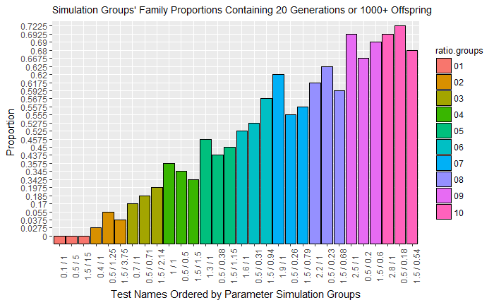

```r
mcGridAlive = sapply(new.mcGrid, function(oneParamSet) {
        sum((oneParamSet[1,] == 20) | (oneParamSet[2,] > 1000)) /
            length(oneParamSet[2,]) })
test.names <- paste(new.lambdas, "/", new.kappas)
mcGridAlive.df <- as.data.frame(cbind(new.lambdas, new.kappas, test.names, new.ratio, mcGridAlive,
                                      ratio.groups))
mcGridAlive.plot <- ggplot(data=mcGridAlive.df, aes(x=test.names, y=mcGridAlive, fill=ratio.groups,
                                                    group=test.names)) +
    scale_x_discrete(limits=mcGridAlive.df$test.names) +
    geom_bar(stat="identity", position=position_dodge(), color="black") +
    labs(title = "Simulation Groups' Family Proportions Containing 20 Generations or 1000+ Offspring ",
         x = "Test Names Ordered by Parameter Simulation Groups", y = "Proportion") +
    theme(plot.title = element_text(size = 10.5), axis.text.x = element_text(angle = 90), legend.title = element_text(size = 10))
plot(mcGridAlive.plot)
```

Another test we used was measuring the proportion of simulations with 20 or more offspring, as shown below. The output is again a bar chart showing each combination of lamdba and kappa values, representing the ratio group each parameter combination is assigned to. The y-axis shows the proportion that contain 20 or more offspring. There is again a clear correlation between the ratio value and the proportion of families containing 20 or more offspring. As the lambda/c ratio increases, so does the proportion. While both these bar charts look practically identical, they are unique in that they show different relationships based on generations and offspring.

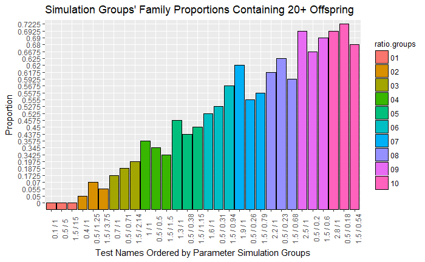

```r
mcGridProp20kids = sapply(new.mcGrid, function(oneParamSet) {
    sum(oneParamSet[2,] > 19) / length(oneParamSet[2,]) })
test.names <- paste(new.lambdas, "/", new.kappas)
mcGridProp20kids.df <- as.data.frame(cbind(new.lambdas, new.kappas, test.names, new.ratio, mcGridProp20kids,
                                      ratio.groups))
mcGridProp20kids.plot <- ggplot(data=mcGridProp20kids.df, aes(x=test.names, y=mcGridProp20kids, fill=ratio.groups,
                                                    group=test.names)) +
    scale_x_discrete(limits=mcGridProp20kids.df$test.names) +
    geom_bar(stat="identity", position=position_dodge(), color="black") +
    labs(title = "Simulation Groups' Family Proportions Containing 20+ Offspring ",
         x = "Test Names Ordered by Parameter Simulation Groups", y = "Proportion") +
    theme(plot.title = element_text(size = 13.5), axis.text.x = element_text(angle = 90), legend.title = element_text(size = 10))
plot(mcGridProp20kids.plot)
```

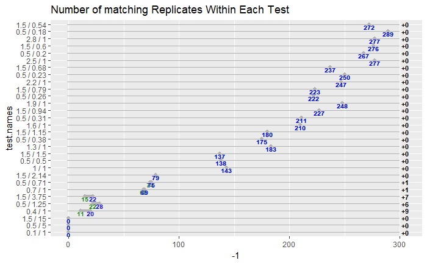

```r
mcGridAlive = sapply(new.mcGrid, function(oneParamSet) {
  sum((oneParamSet[1,] == 20) | (oneParamSet[2,] > 1000)) })
mcGridAlive = as.numeric(as.character(mcGridAlive))
mcGridProp20kids = sapply(new.mcGrid, function(oneParamSet) {
  sum(oneParamSet[2,] > 19)})
mcGridProp20kids = as.numeric(as.character(mcGridProp20kids))
df <- data.frame(test.names, mcGridAlive, mcGridProp20kids)
df$diff <- sprintf("+%d", as.numeric(mcGridProp20kids-mcGridAlive))
#formattable(df)
gg <- ggplot()
# doing this vs y axis major grid line
gg <- gg + geom_segment(data=df, aes(y=test.names, yend=test.names, x=-1, xend=300), color="#b2b2b2", size=0.15)
# dum.dum.dum!bell
gg <- gg + geom_dumbbell(data=df, aes(y=test.names, x=mcGridAlive, xend=mcGridProp20kids),
                         size=1.5, color="#b2b2b2", point.size.l=3, point.size.r=3,
                         point.colour.l="#9fb059", point.colour.r="#edae52")
# text above points
gg <- gg + geom_text(data=df, aes(x=mcGridAlive, y=test.names, label=mcGridAlive), fontface="bold",
                     color="#008000", size=2.75, vjust=1)
gg <- gg + geom_text(data=df, color="#0000ff", size=2.75, vjust=1,
                     aes(x=mcGridProp20kids, y=test.names, label=mcGridProp20kids), fontface="bold")
gg <- gg + scale_y_discrete(limits=df$test.names)
# difference column
gg <- gg + geom_text(data=df, aes(label=diff, y=test.names, x=305), fontface="bold", size=3)
gg <- gg + labs(title="Number of matching Replicates Within Each Test")
gg
```

## References

[1] D. Lang and D. Nolan, Data Science in R: A Case Studies Approach to Computation Reasoning and Problem Solving. New York, New York: CRC Press.

[2] John Tsitsiklis, Christos Papadimitriou, and Pierre Humblet. The Performance of a Precedence-Based Queuing Discipline. Journal of the Association for Computing Machinery , 33:593â“602, 1986.

[3] David Aldous and William Krebs. The âBirth-and-Assassinationâ Process. Statistics and Probability Letters, 10:427â“430, 1990.